# Socially-Funded Loans on Prosper

## by Tom Schonig

## Dataset Overview

The dataset in consideration was curated by Udacity, but originated from Prosper.com. The dataset contains information about loans listed on Prosper from November 2005 through March 2014. The original dataset contained 113,937 across 81 variables - however, my wrangling uncovered 871 duplicate listings that were removed prior to analysis (for a "cleaned" total of 113,066 records).

## Investigation Overview

I began this investigation with some background knowledge of finance and banking, but no hand-on experience with Peer-to-Peer lending platforms - so I had many open-ended questions. Initially, I wanted to get a sense of the overall Prosper book of business - who were they lending to, and under what terms? How did the loans compare to traditional lenders? Etc...

Rather than fixate on a few variables that, based on intuition (or some lesser compulsion) looked interesting, I resolved to find a way to programmatically plot and evaluate all the variables in the dataset. I wanted to deeply understand it, and knew that my questions would be refined as I better contextualized the data.

As I began plotting each variable and the correlations between them, it dawned on me the unique differentiator of Peer-to-Peer lending: ideally, it actually facilitates lending between people who know eachother. I kept remembering J.P. Morgan's biography and his legendary comments to Congress..

Samuel Untermeyer: "Is not commercial credit based primarily upon money or property?"

J.P. Morgan: "No, sir; the first thing is character."

Samuel Untermeyer: "Before money or property?"

J.P. Morgan: "Before money or anything else. Money cannot buy it.”

While I've informally loaned people money before, I've never really thought about those types of transactions in-macro, and how my first-hand knowledge of the borrower may impact repayment and other loan attributes. The Prosper data gave a window into how some of these types of transactions perform when formalized and standardized as a legally-binding loan. Accordingly, I locked onto this as the main thread for deeper investigation.

## Prosper's Book of Business

Prosper is a Peer-to-Peer lending service that facilitates an open marketplace for personal loans, which has grown rapidly in the recovery after the Financial Crisis. Over the years, the platform has made enhancements aimed to make it safer for most investors - and delinquency rates have fallen in response.

However, changes to the platform also include removing certain social features, like the ability for borrowers to solict funding from their friends. These features were never widely used, with only a small number of loans listed between 2007 and 2011 utilizing the feature.

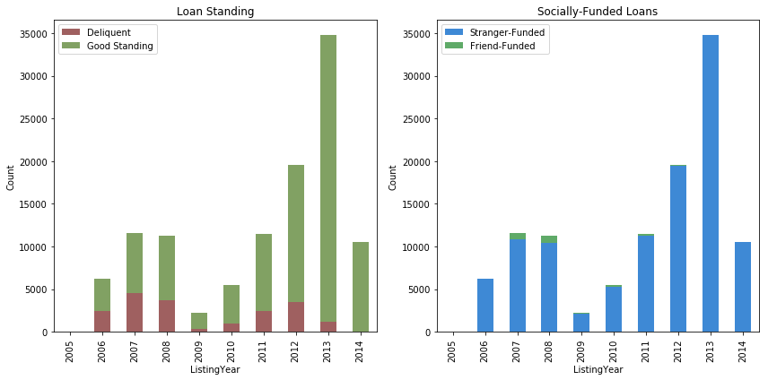

```python
fig = plt.figure(figsize=[12,6])
gs = gridspec.GridSpec(1,2)
ax1 = plt.subplot(gs[0])
ax2 = plt.subplot(gs[1])

ax1.set_title('Loan Standing')
ax2.set_title('Socially-Funded Loans')

ax1.set_ylabel('Count')
ax2.set_ylabel('Count')


df_plot_standing.plot(kind='bar',stacked=True,ax=ax1,color=['#9f6060','#81a163'])
df_plot_socialfunded.plot(kind='bar',stacked=True,ax=ax2, color=['#3e89d5','#5faa68'])
ax1.legend(labels=['Deliquent','Good Standing'])
ax2.legend(labels=['Stranger-Funded','Friend-Funded'])
plt.tight_layout()
plt.show()
```

## How Do Social Borrowers Differ?

Using the Internet Archive, we can visit Prosper's old websites and see that they used to market socially-funded loans as less risky. And there appears to be evidence to support that.

The borrowers soliciting funding from their friends on Prosper appear to be more responsible users of credit - they had both fewer total dollars deliquent across their credit lines, and were using Prosper to take out smaller loans, compared other borrowers. Even more, there was much less variability among these borrowers compared to borrowers on Prosper asking strangers for money.

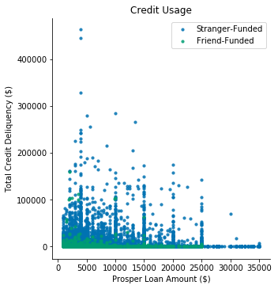

```python
jitter = .01
sb.lmplot(x='LoanOriginalAmount',y='AmountDelinquent',data=df_clean,fit_reg=False,hue='HasSocialInvestment',legend=False,x_jitter=jitter,y_jitter=jitter,scatter_kws={"s": 10})
plt.legend(labels=['Stranger-Funded','Friend-Funded'])
plt.ylabel("Total Credit Deliquency ($)")
plt.xlabel("Prosper Loan Amount ($)")
plt.title("Credit Usage")
plt.show()
```

## How Do Friend-Funded Loans Perform?

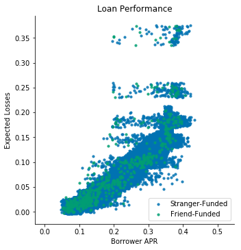

```python
jitter = .01
sb.lmplot(x='BorrowerAPR',y='EstimatedLoss',data=df_clean,fit_reg=False,hue='HasSocialInvestment',legend=False,x_jitter=jitter,y_jitter=jitter,scatter_kws={"s": 10})
plt.legend(labels=['Stranger-Funded','Friend-Funded'])
plt.ylabel("Expected Losses")
plt.xlabel("Borrower APR")
plt.title("Loan Performance")
plt.show()
```